# pisa_visualization_exploratory_analysis

```python
import numpy as np
import pandas as pd
import matplotlib.pyplot as plt
import seaborn as sb
%matplotlib inline
```

```python
data_raw = pd.read_csv('pisa2012.csv')
```

```python
#resize data set
data = data_raw[['CNT',
                 'OECD',
                 'ST43Q01',
                 'ST42Q02',
                 'ST26Q06',
                 'ST26Q04',
                 'ST19Q01',
                 'ST17Q01',
                 'ST15Q01',
                 'ST13Q01',
                 'ST04Q01',
                 'PV1MATH',
                 'PV1READ',
                 'PV1SCIE']]
```

```python
#rename column names
data = data.rename(columns={"CNT" : "country",
                     "OECD" : "oecd",
                     "ST43Q01" : "control",
                     "ST42Q02" : "self_concept",
                     "ST26Q06" : "internet",
                     "ST26Q04" : "computer",
                     "ST19Q01" : "father_job_status",
                     "ST17Q01" : "father_school",
                     "ST15Q01" : "mother_job_status",
                     "ST13Q01" : "mother_school",
                     "ST04Q01" : "gender",
                     "PV1MATH" : "math",
                     "PV1READ" : "read",
                     "PV1SCIE" : "science"})
```

```python
data.head()
```

|  | country | oecd | control | self_concept | internet | computer | father_job_status | father_school | mother_job_status | mother_school | gender | math | read | science |
| --- | --- | --- | --- | --- | --- | --- | --- | --- | --- | --- | --- | --- | --- | --- |
| 0 | Albania | Non-OECD | Agree | Disagree | No | No | Working part-time <for pay> | <ISCED level 3A> | Other (e.g. home duties, retired) | <ISCED level 3A> | Female | 406.8469 | 249.5762 | 341.7009 |
| 1 | Albania | Non-OECD | Strongly agree | NaN | Yes | Yes | Working full-time <for pay> | <ISCED level 3A> | Working full-time <for pay> | <ISCED level 3A> | Female | 486.1427 | 406.2936 | 548.9929 |
| 2 | Albania | Non-OECD | Strongly agree | NaN | Yes | Yes | Working full-time <for pay> | <ISCED level 3A> | Working full-time <for pay> | <ISCED level 3B, 3C> | Female | 533.2684 | 401.2100 | 499.6643 |
| 3 | Albania | Non-OECD | NaN | Strongly agree | Yes | Yes | Working full-time <for pay> | <ISCED level 3A> | Working full-time <for pay> | <ISCED level 3B, 3C> | Female | 412.2215 | 547.3630 | 438.6796 |
| 4 | Albania | Non-OECD | Strongly agree | Strongly agree | Yes | Yes | Working part-time <for pay> | <ISCED level 3B, 3C> | Working part-time <for pay> | She did not complete <ISCED level 1> | Female | 381.9209 | 311.7707 | 361.5628 |

```python
data.info()

#data type for control, self concept, job status of father and mother and education of father and mother needs to be
#adjusted
```

```
<class 'pandas.core.frame.DataFrame'>
RangeIndex: 485490 entries, 0 to 485489
Data columns (total 14 columns):
 #   Column             Non-Null Count   Dtype
---  ------             --------------   -----
 0   country            485490 non-null  object
 1   oecd               485490 non-null  object
 2   control            314971 non-null  object
 3   self_concept       313502 non-null  object
 4   internet           473182 non-null  object
 5   computer           473877 non-null  object
 6   father_job_status  451410 non-null  object
 7   father_school      443261 non-null  object
 8   mother_job_status  467751 non-null  object
 9   mother_school      457979 non-null  object
 10  gender             485490 non-null  object
 11  math               485490 non-null  float64
 12  read               485490 non-null  float64
 13  science            485490 non-null  float64
dtypes: float64(3), object(11)
memory usage: 51.9+ MB
```

```python
#include order for categorical variables
classes = ['Strongly agree', 'Agree', 'Disagree', 'Strongly disagree']
cclasses = pd.api.types.CategoricalDtype(ordered=True, categories=classes)
data['control'] = data['control'].astype(cclasses);
```

```python
sclasses = pd.api.types.CategoricalDtype(ordered=True, categories=classes)
data['self_concept'] = data['self_concept'].astype(sclasses);
```

```python
statusclasses = ['Working full-time <for pay> ', 'Working part-time <for pay>', 'Not working, but looking for a job', 'Other (e.g. home duties, retired) ']
stclasses = pd.api.types.CategoricalDtype(ordered=True, categories=statusclasses)
data['father_job_status'] = data['father_job_status'].astype(stclasses);
```

```python
cclasses = pd.api.types.CategoricalDtype(ordered=True, categories=statusclasses)
data['mother_job_status'] = data['mother_job_status'].astype(stclasses);
```

```python
motherclasses = ['<ISCED level 3B, 3C> ', '<ISCED level 3A> ', '<ISCED level 2> ', '<ISCED level 1> ', 'No <ISCED level 1> ']
mclasses = pd.api.types.CategoricalDtype(ordered=True, categories=motherclasses)
data['mother_school'] = data['mother_school'].astype(mclasses);
```

```python
fatherclasses = ['<ISCED level 3B, 3C> ', '<ISCED level 3A> ', '<ISCED level 2> ', '<ISCED level 1> ', 'No <ISCED level 1> ']
fclasses = pd.api.types.CategoricalDtype(ordered=True, categories=fatherclasses)
data['father_school'] = data['father_school'].astype(fclasses);
```

```python
#check changes
data.info()
```

```
<class 'pandas.core.frame.DataFrame'>
RangeIndex: 485490 entries, 0 to 485489
Data columns (total 14 columns):
 #   Column             Non-Null Count   Dtype
---  ------             --------------   -----
 0   country            485490 non-null  object
 1   oecd               485490 non-null  object
 2   control            314971 non-null  category
 3   self_concept       313502 non-null  category
 4   internet           473182 non-null  object
 5   computer           473877 non-null  object
 6   father_job_status  451410 non-null  category
 7   father_school      426726 non-null  category
 8   mother_job_status  436173 non-null  category
 9   mother_school      439211 non-null  category
 10  gender             485490 non-null  object
 11  math               485490 non-null  float64
 12  read               485490 non-null  float64
 13  science            485490 non-null  float64
dtypes: category(6), float64(3), object(5)
memory usage: 32.4+ MB
```

```python
#check duplicated data
data.duplicated().sum()
```

```
0
```

```python
#count missing data
data.isnull().sum()

#most data missing for self concept and control
#some data missing for job status of father and mother and education of father and mother
#few data missing for internet and computer access
```

```
country                   0
oecd                      0
control              170519
self_concept         171988
internet              12308
computer              11613
father_job_status     34080
father_school         58764
mother_job_status     49317
mother_school         46279
gender                    0
math                      0
read                      0
science                   0
dtype: int64
```

Most data is missing for self concept and control. Some data is missing for job status of father and mother and education of father and mother. Few data is missing for internet and computer access.

```python
base_color = sb.color_palette()[0]
```

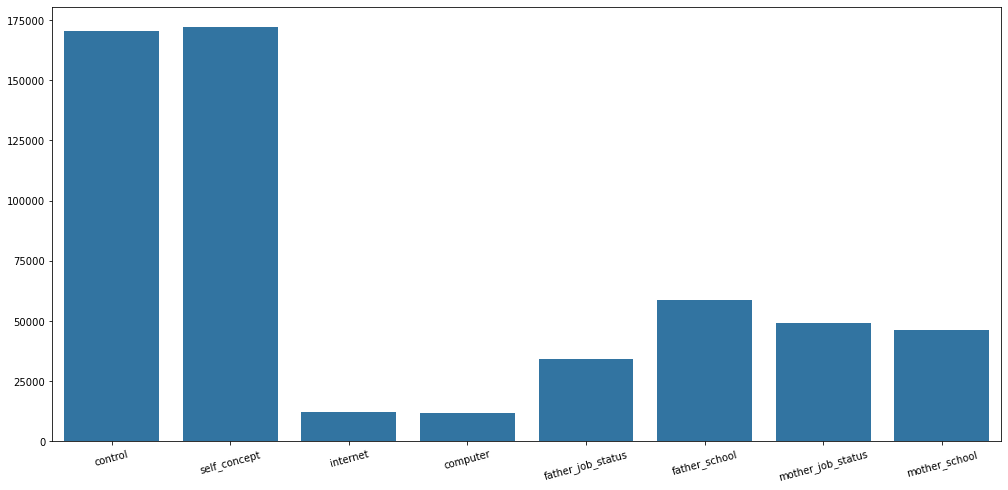

```python
#visualize missing data
data.isnull().sum()
na_counts = data.drop(['country', 'oecd', 'gender', 'math', 'read', 'science'], axis=1).isna().sum()

plt.figure(figsize=(17,8))
sb.barplot(na_counts.index.values, na_counts, color=base_color)
plt.xticks(rotation=15);
```

## Goal of analysis

Variables 'math', 'read' and 'science' are dependent variables.

Other variables are independent variables.

Questions:

- What influence does belonging to OECD have on the dependent variables?
- What influence does the gender of the student have on the dependent variables?
- What influence does the access to a computer have on the dependent variable?
- What influence does the access to the internet have on the dependent variable?
- What influence does the self concept of students ('I am good at math') have on the dependent variable?
- What influence does the perceived control of students have on the dependent variable?
- What influence does the education of mother / father have on the dependent variables?
- What influence does the job status of mother/father have on the dependent variables?
- What influence does the country (two examples of best and worst country) have on the dependent variables?

## Analysis and visualization of data set

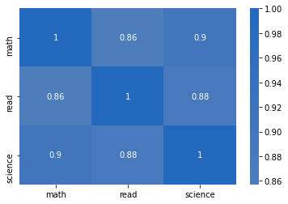

```python
#Variables 'math', 'read' and 'science' are dependent variables.
#Question: Are they highly correlated?

#Visualization of correlation between math, reading and science results

sb.heatmap(data.corr(), annot=True, cmap='vlag_r', center=0);
```

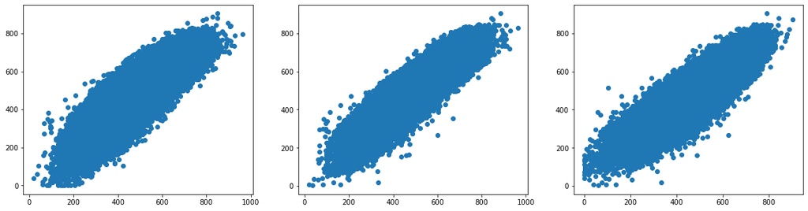

```python
#Visualization of correlation between math, reading and science results

plt.figure(figsize=[20,5])
plt.subplot(1,3,1)
plt.scatter(data=data, x='math', y='read')

plt.subplot(1,3,2)
plt.scatter(data=data, x='math', y='science')

plt.subplot(1,3,3)
plt.scatter(data=data, x='read', y='science');
```

Correlations between the dependent variables are high. Therefore, one dependent variable ('math') is mainly used for the analysis.

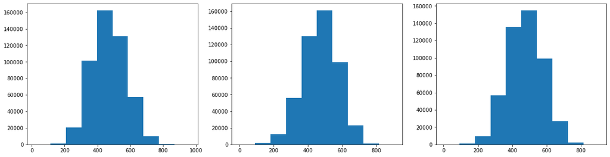

```python
#Visualization of distribution of math, reading and science results

plt.figure(figsize=[20,5])
plt.subplot(1,3,1)
plt.hist(data=data, x='math', bins=10);

plt.subplot(1,3,2)
plt.hist(data=data, x='read', bins=10);

plt.subplot(1,3,3)
plt.hist(data=data, x='science', bins=10);
```

Average results in math, reading and science show similar (normal) distribution.

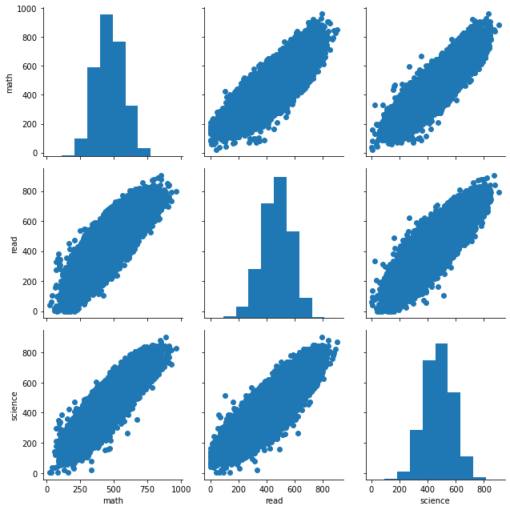

```python
#Visualization of distruption and correlation between math, reading and science results

g = sb.PairGrid(data=data, vars=['math', 'read', 'science'], size=3)
g.map_diag(plt.hist)
g.map_offdiag(plt.scatter);
```

```python
base_color = sb.color_palette()[0]
```

### What influence does belonging to OECD have on the dependent variables?

```python
oecd = data.query('oecd == "OECD"')
non_oecd = data.query('oecd == "Non-OECD"')
```

```python
#Count number of students from OECD countries
oecd.country.value_counts().sum()
```

```
295416
```

```python
#Count number of students from Non-OECD countries
non_oecd.country.value_counts().sum()

#There are more students from OECD countries taking part in the pisa study which might influence the results.
```

```
190074
```

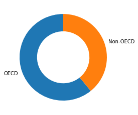

```python
#Visualization of relative frequency of OECD and Non-OECD countries

x = data.oecd.unique()
y = data.oecd.value_counts(sort=False)

plt.pie(y, labels = y.index, startangle = 90, wedgeprops = {'width' : 0.4});
```

```python
#Analyze average math results in OECD countries
oecd.math.mean()
```

```
488.3477719121733
```

```python
#Analyze average math results in Non-OECD countries
non_oecd.math.mean()

#The average math score in OECD countries is higher than in non-oecd countries (by 48 points).
```

```
440.5172247256306
```

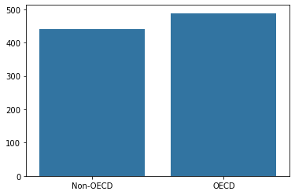

```python
#Visualization of average math results of students in OECD and Non-OECD countries

oecd_mean = data.groupby(['oecd']).mean()

x = oecd_mean.index.values
y = oecd_mean.math.values

sb.barplot(x, y, color=base_color);
```

Average math results of students in OECD countries are better.

[output not shown]

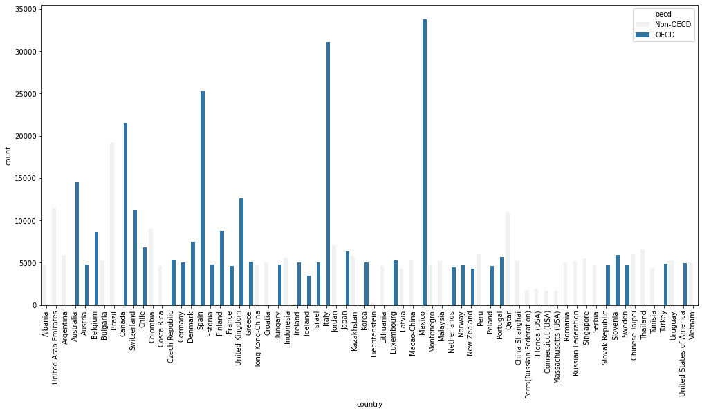

```python
#Visualization of participating students per countries (OECD and Non-OECD countries are marked)
plt.figure(figsize=(17,8))
g = sb.countplot(data=data, x='country', hue='oecd', color=base_color)
g.set_xticklabels(g.get_xticklabels(), rotation=90)
```

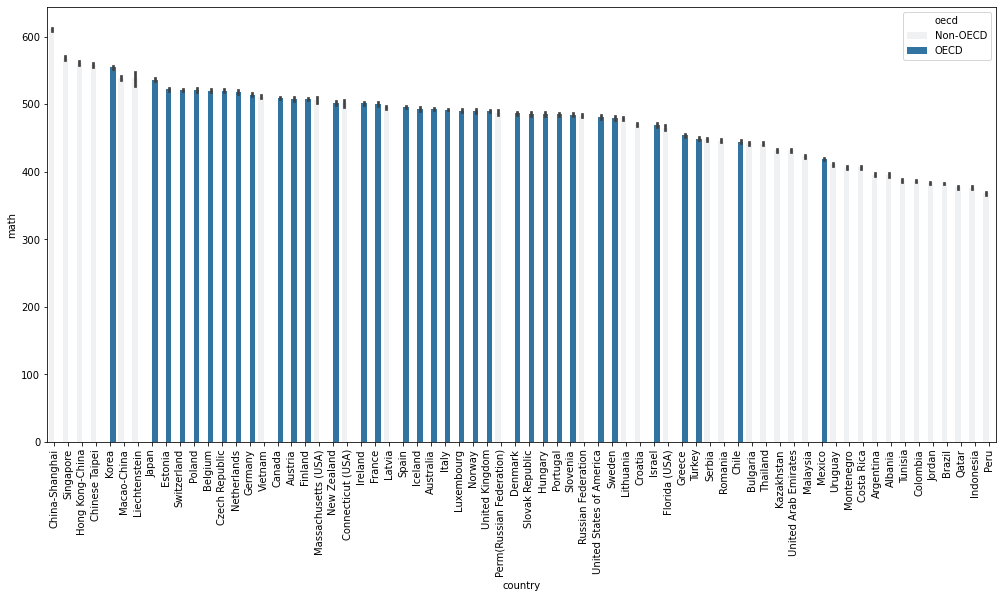

```python
#Visualization of average math results per countries (OECD and Non-OECD countries are marked)

country_mean = data.groupby(['country']).mean()
country_mean_math_sort = country_mean.sort_values(by=['math'], ascending=False)
order = country_mean_math_sort.index

plt.figure(figsize=(17,8))
g = sb.barplot(data=data, x='country', y='math', hue='oecd', color=base_color, order=order)
plt.xticks(rotation=90);
```

There are significant differences between the countries. However, there is no clear trend visible in regard to OECD countries as the best and the worst countries are Non-OECD countries.

### What influence does the gender of the student have on the dependent variables?

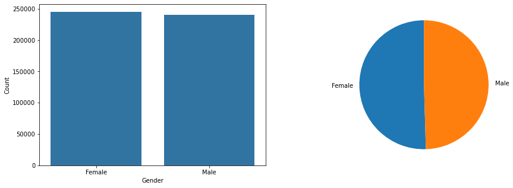

```python
#Visualization of participating students per gender

plt.figure(figsize=(15,5))

plt.subplot(1,2,1)
g = sb.countplot(data=data, x='gender', color=base_color, order=['Female', 'Male'])
g.set(xlabel='Gender', ylabel='Count')

plt.subplot(1,2,2)
y = data.gender.value_counts()
plt.pie(y, labels=y.index, startangle=90);
```

Almost the same amount of male and female students are represented in the data set.

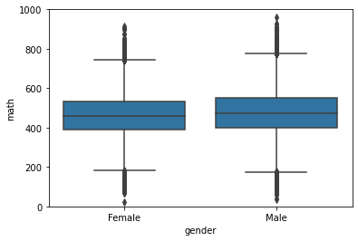

```python
#Visualization of average math results per gender

g = sb.boxplot(data=data, x='gender', y='math', color=base_color);
g.set_ylim(0,1000);
```

Male students achieve better math results on average.

### What influence does the access to a computer have on the dependent variable?

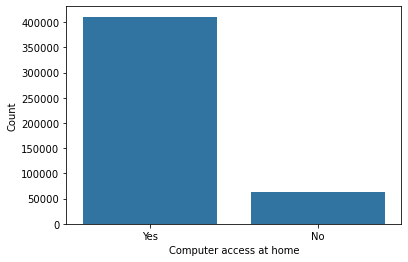

```python
#Visualization of participating students depending on computer access

g = sb.countplot(data=data, x='computer', color=base_color, order=['Yes', 'No'])
g.set(xlabel='Computer access at home', ylabel='Count');
```

Most students have access to a computer at home.

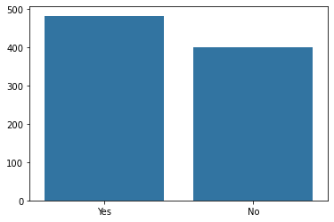

```python
#Visualization of average math results depending on computer access

computer_mean = data.groupby(['computer']).mean()

x = computer_mean.index.values
y = computer_mean.math.values

sb.barplot(x, y, color=base_color, order=['Yes', 'No']);
```

Students that have access to a computer achieve better average math results.

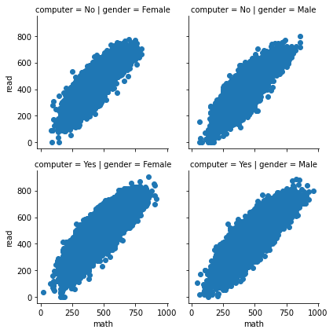

```python
#Visualization of correlation between math and reading results, sorted by gender and computer access

g = sb.FacetGrid(data= data, col = 'gender', row='computer')
g.map(plt.scatter, 'math', 'read');
```

### What influence does the access to a internet have on the dependent variable?

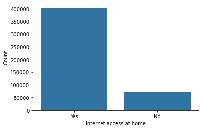

```python
#Visualization of participating students depending on internet access

g = sb.countplot(data=data, x='internet', color=base_color, order=['Yes', 'No'])
g.set(xlabel='Internet access at home', ylabel='Count');
```

Most students have internet access at home.

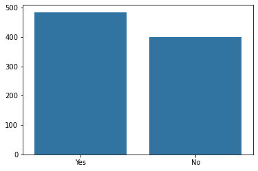

```python
#Visualization of average math results depending on internet access

internet_mean = data.groupby(['internet']).mean()

x = internet_mean.index.values
y = internet_mean.math.values

sb.barplot(x, y, color=base_color, order=['Yes', 'No']);
```

Students that have internet access achieve better average math results.

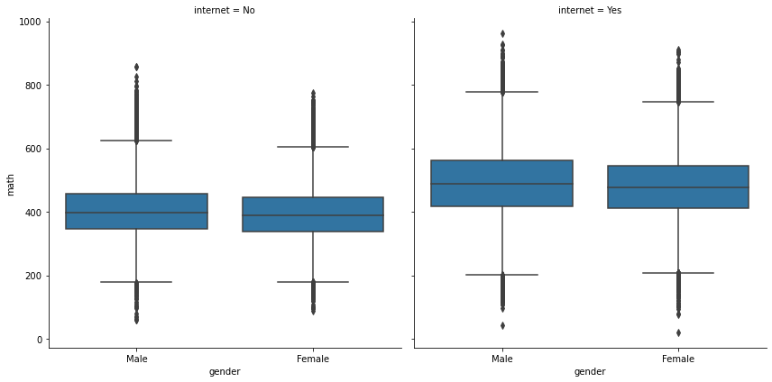

```python
#Visualization of average math results depending on internet access and sorted by gender

g = sb.FacetGrid(data=data, col='internet', size=6)
g.map(sb.boxplot, 'gender', 'math', order=['Male', 'Female']);
```

Male students outperform female students in both categories.

### What influence does the self concept of students ('I am good at math') have on the dependent variable?

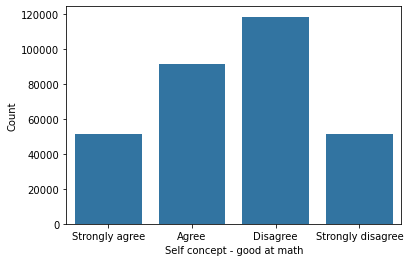

```python
#Visualization of frequency of answers in regard to self concept

g = sb.countplot(data=data, x='self_concept', color=base_color)
g.set(xlabel='Self concept - good at math', ylabel='Count');
```

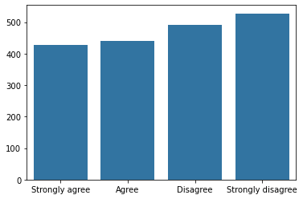

```python
#Visualization of average math results depending on self concept

self_concept_mean = data.groupby(['self_concept']).mean()

x = self_concept_mean.index.values
y = self_concept_mean.math.values

sb.barplot(x, y, color=base_color);
```

The more students disagree with the statement that they are not good at math, the better their average math results are.

### What influence does the perceived control of students have on the dependent variable?

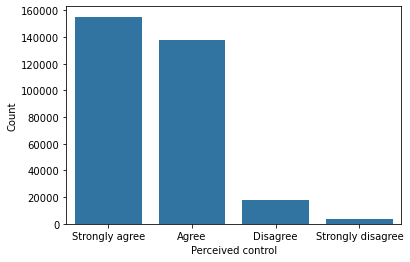

```python
#Visualization of frequency of answers in regard to perceived control

g = sb.countplot(data=data, x='control', color=base_color)
g.set(xlabel='Perceived control', ylabel='Count');
```

Most students 'Strongly agree' followed by 'Agree' with the statement that more effort leads to better results.

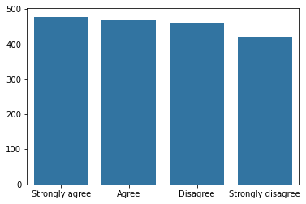

```python
#Visualization of average math results depending on perceived control

control_mean = data.groupby(['control']).mean()

x = control_mean.index.values
y = control_mean.math.values

sb.barplot(x, y, color=base_color);
```

The more students agree with the statement that more effort leads to better results, the better their average math results are.

### What influence does the education of mother / father have on the dependent variables?

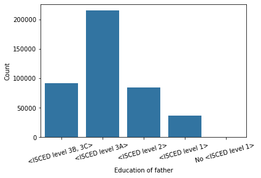

```python
#Visualization of frequency of highest achieved education of fathers

g = sb.countplot(data=data, x='father_school', color=base_color)
g.set_xticklabels(g.get_xticklabels(), rotation=15)
g.set(xlabel='Education of father', ylabel='Count');
```

Most fathers achieve ISCED level 3A.

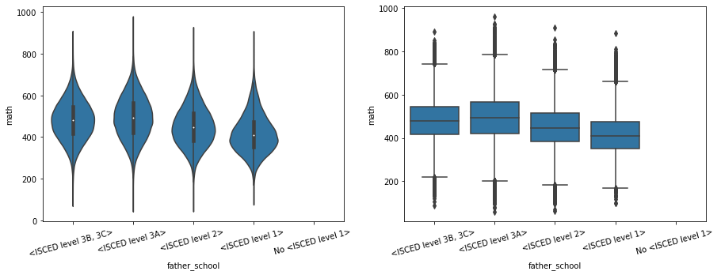

```python
#Visualization of average math results depending on education of their fathers

plt.figure(figsize=(15,5))

plt.subplot(1,2,1)
sb.violinplot(data=data, x='father_school', y='math', color=base_color)
plt.xticks(rotation=15);

plt.subplot(1,2,2)
sb.boxplot(data=data, x='father_school', y='math', color=base_color)
plt.xticks(rotation=15);
```

Students which fathers achieved ISCED level 3A achieved the best average math results.

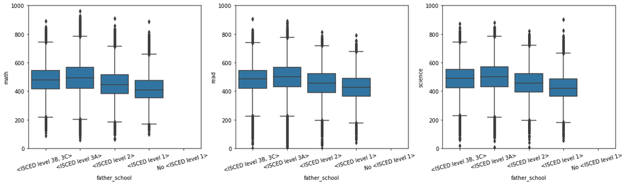

```python
#Visualization of average math, reading and science results depending on education of their fathers

father_school_mean = data.groupby(['father_school']).mean()

plt.figure(figsize=[20,5])
plt.subplot(1,3,1)

g = sb.boxplot(data=data, x='father_school', y='math', color=base_color)
g.set_ylim(0, 1000)
plt.xticks(rotation=15)

plt.subplot(1,3,2)
g = sb.boxplot(data=data, x='father_school', y='read', color=base_color)
g.set_ylim(0, 1000)
plt.xticks(rotation=15)

plt.subplot(1,3,3)
g = sb.boxplot(data=data, x='father_school', y='science', color=base_color)
g.set_ylim(0, 1000)
plt.xticks(rotation=15);
```

Students which fathers achieved ISCED level 3A achieved the best average math, reading and science results.

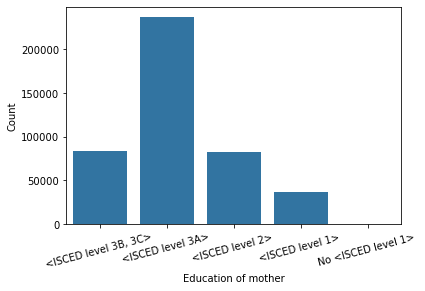

```python
#Visualization of frequency of highest achieved education of mothers

g = sb.countplot(data=data, x='mother_school', color=base_color)
g.set_xticklabels(g.get_xticklabels(), rotation=15)
g.set(xlabel='Education of mother', ylabel='Count');
```

Most mothers achieve ISCED level 3A.

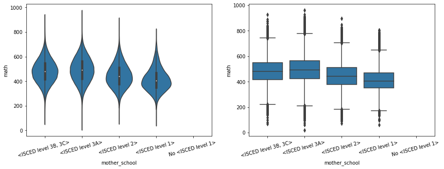

```python
#Visualization of average math results depending on education of their mothers

data.groupby(['mother_school']).mean()

plt.figure(figsize=(15,5))

plt.subplot(1,2,1)
sb.violinplot(data=data, x='mother_school', y='math', color=base_color)
plt.xticks(rotation=15);

plt.subplot(1,2,2)
sb.boxplot(data=data, x='mother_school', y='math', color=base_color)
plt.xticks(rotation=15);
```

Students which mothers achieved ISCED level 3A achieved the best average math results.

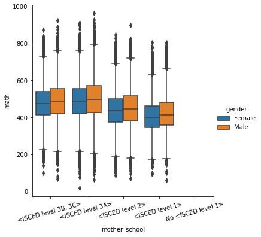

```python
#Visualization of average math results depending on education of their mothers and their gender

sb.catplot(data=data, x="mother_school", y="math", hue="gender", kind="box")
plt.xticks(rotation=15);
```

Male students perform slightly better compared to female students independent of education of their mothers.

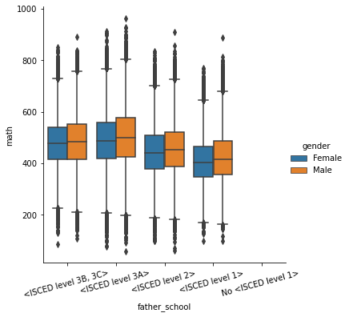

```python
#Visualization of average math results depending on education of their fathers and their gender

sb.catplot(data=data, x="father_school", y="math", hue="gender", kind="box")
plt.xticks(rotation=15);
```

Male students perform slightly better compared to female students independent of education of their fathers.

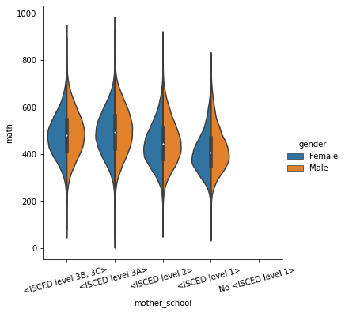

```python
#Visualization of average math results depending on education of their mothers and their gender

sb.catplot(data=data, x="mother_school", y="math", hue="gender", kind="violin", split=True)
plt.xticks(rotation=15);
```